## Loading and preprocessing the data

Load the data

```r
data <- read.csv("C:\\Users\\8.1\\Documents\\data\\activity.csv")
```

## What is mean total number of steps taken per day?

Ignore the missing values in the dataset

```r
 good <- complete.cases(data)
data1 <- data[good,]
```

Calculate the total number of steps taken per day

```r
total <- with(data1, tapply(steps, date, sum, na.rm = T))
```

Histogram of the total number of steps taken each day

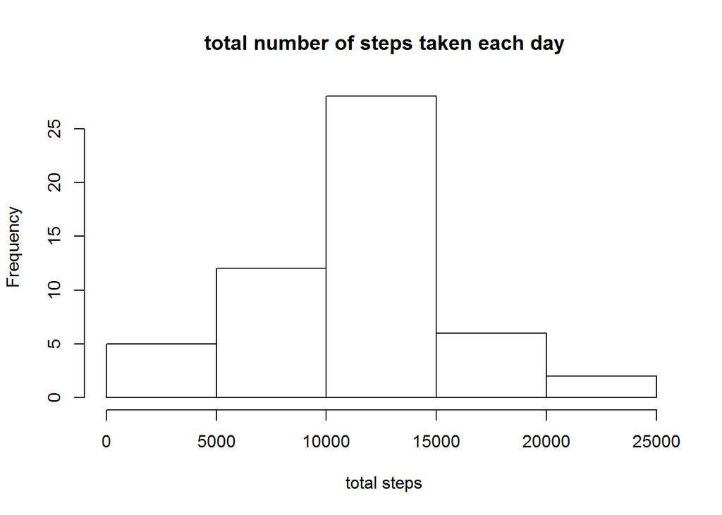

```r
d1 <- data.frame(date = names(total), totalsteps = total)
hist(d1$totalsteps, xlab = " total steps", main = " total number of steps taken each day")
```

Calculate and report the mean and median of the total number of steps taken per day

```r
summary(total)
```

```
##    Min. 1st Qu.  Median    Mean 3rd Qu.    Max.    NA's
##      41    8841   10765   10766   13294   21194       8
```

Mean of total number of steps per day is 10766, median is 10765.

## What is the average daily activity pattern?

Time series plot of the average number of steps taken

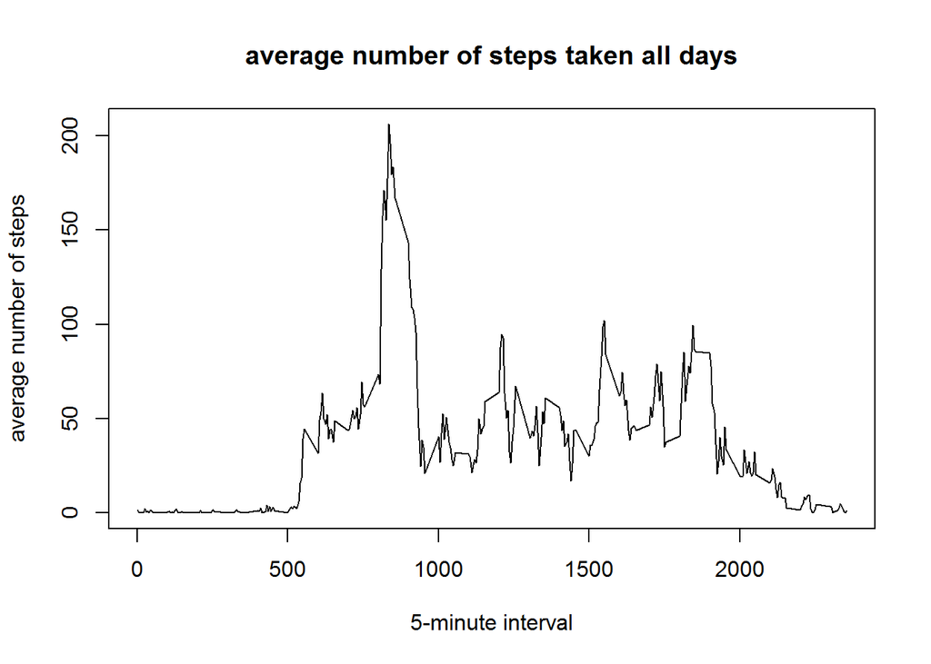

```r
avgstepsperday <- aggregate(steps ~ interval , FUN = mean, data = data1)
with(avgstepsperday, plot(x= interval , y =steps, xlab = "5-minute interval", type = "l" , ylab = "average number of steps", main = "average number of steps taken all days"))
```

The 5-minute interval that, on average, contains the maximum number of steps

```r
stepsmax <- which.max(avgstepsperday$steps)
avgstepsperday[stepsmax,]
```

```
##     interval    steps
## 104      835 206.1698
```

The interval 835 has the maximum average value of steps (206.1698)

## Imputing missing values

Calculate and report the total number of missing values in the dataset

```r
sum(is.na(data))
```

```
## [1] 2304
```

Create a new dataset that is equal to the original dataset but with the missing data filled in

```r
imputed_Data <- data
imputed_Data$steps[is.na(imputed_Data$steps)] <- mean(imputed_Data$steps, na.rm = T)
```

Make a histogram of the total number of steps taken each day

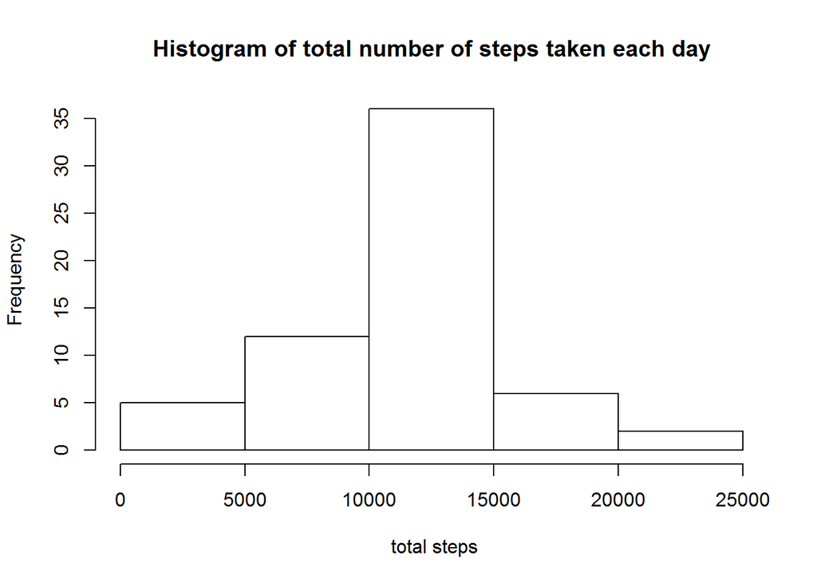

```r
total1 <- with(imputed_Data, tapply(steps, date, sum))
d2 <- data.frame(date = names(total1), totalsteps = total1)
hist(d2$totalsteps, xlab = " total steps", main = "Histogram of total number of steps taken each day")
```

Calculate and report the mean and median total number of steps taken per day

```r
summary(total1)
```

```
##    Min. 1st Qu.  Median    Mean 3rd Qu.    Max.
##      41    9819   10766   10766   12811   21194
```

So, after imputing the missing data, the new mean of total steps taken per day is the same as that of the old mean; the new median of total steps taken per day is greater than that of the old median.

## Are there differences in activity patterns between weekdays and weekends?

Create a new factor variable in the dataset with two levels - “weekday” and “weekend”

```r
imputed_Data$date <- as.Date(imputed_Data$date)
imputed_Data$weekdays <- weekdays(imputed_Data$date)
imputed_Data$weeks[(imputed_Data$weekdays == "Saturday" | imputed_Data$weekdays == "Sunday")] <- "weekend"
imputed_Data$weeks[!(imputed_Data$weekdays == "Saturday" | imputed_Data$weekdays == "Sunday")] <- "weekdays"
```

Make a panel plot containing a time series plot (i.e. type = “l”) of the 5-minute interval (x-axis) and the average number of steps taken, averaged across all weekday days or weekend days (y-axis)

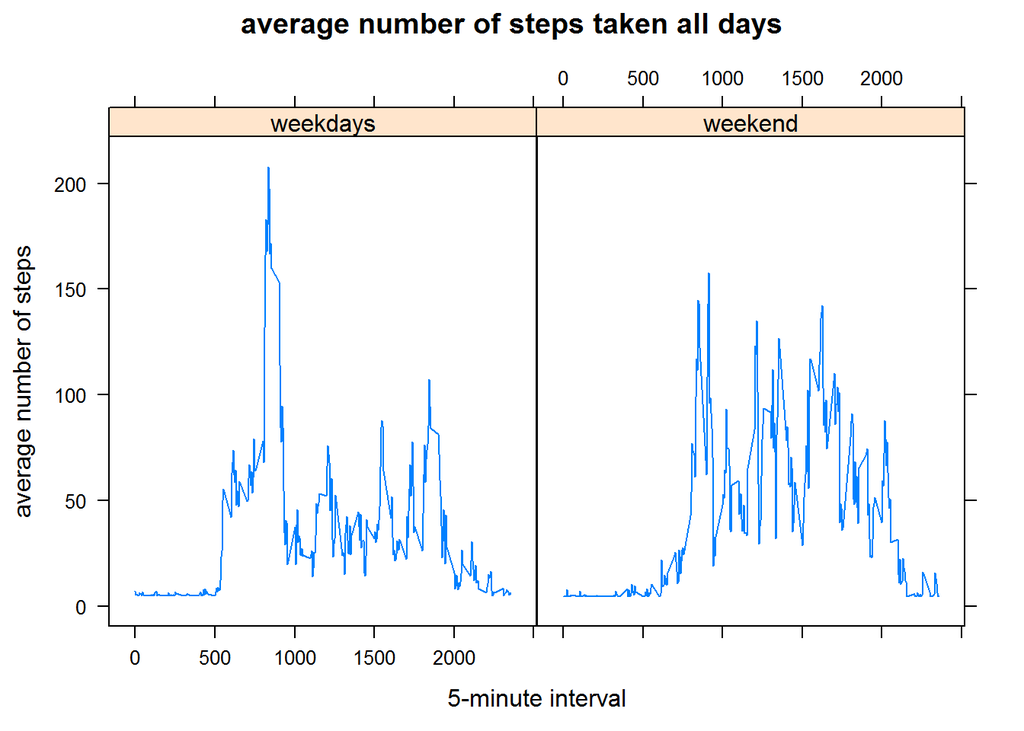

```r
avgstepsperday1 <- aggregate(steps ~ interval + weeks , FUN = mean, data = imputed_Data)
library(lattice)
xyplot(steps ~ interval| weeks, data = avgstepsperday1, xlab = "5-minute interval", type = "l" , ylab = "average number of steps", main = "average number of steps taken all days")
```